# RNA-Seq analysis (part 2)

```r
library(tidyverse)
library(DESeq2)
library(EnhancedVolcano)
library(pheatmap)
```

# 1 Load DESeq data from last time

In part 1, we ran DESeq2’s algorithm and stored the results `Rdata` file (it took a while to run, so I wanted to save time in the future by storing it). Here, we load it in to provide further analysis and visualizations.

```r
load(file.path("./deseq2_output.Rdata"))
```

# 2 PCA

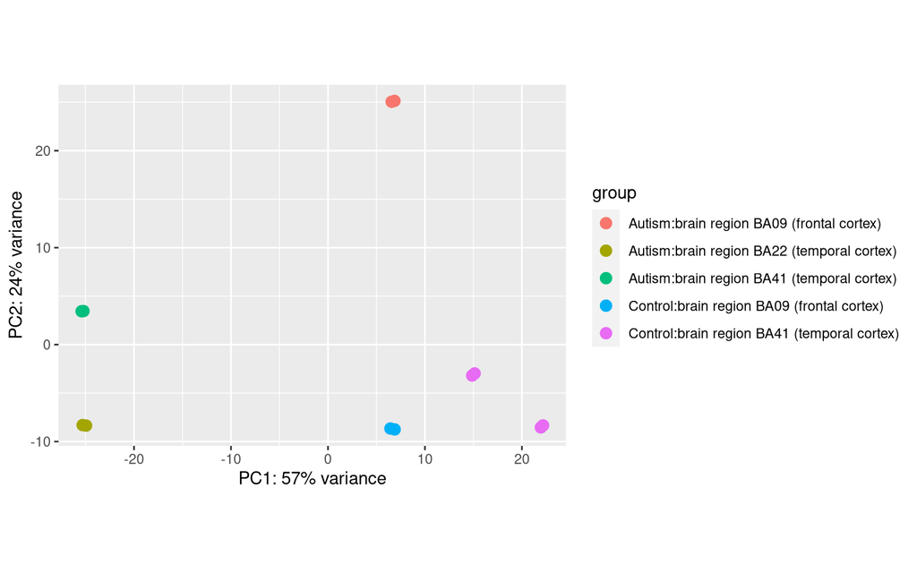

```r
plotPCA(normalized_de_output, intgroup = c("status", "tissue"))
```

# 3 Volcano plot

```r
res <- results(de_output)
```

```r
EnhancedVolcano(
    res,
    lab = "",
    x = "log2FoldChange",
    y = "pvalue",
    title = NULL,
    subtitle = NULL,
    xlim = c(-10, 6),
    pCutoff = 10e-35,
    FCcutoff = 2.0,
    pointSize = 2.0,
    labSize = 4.0,
    legendPosition = "bottom",
    legendLabels = c(
        "Insignificant",
        "Significant in log fold change",
        "Significant in p-value",
        "Significant in both"
    )
)
```

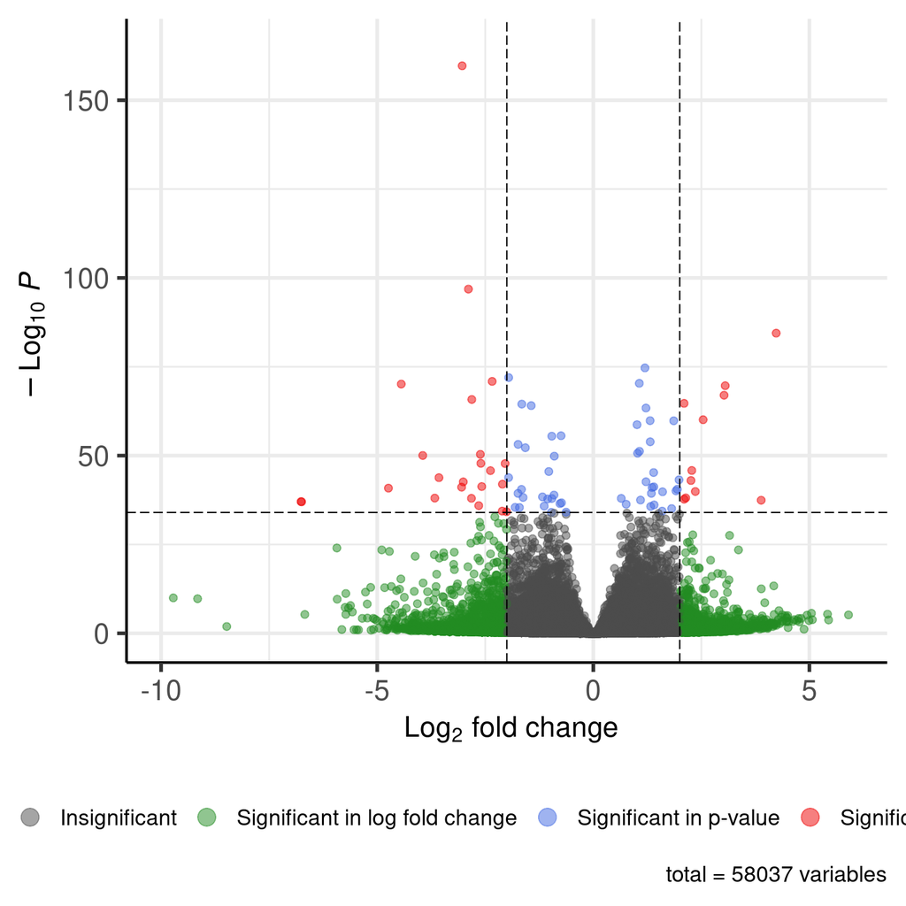

TODO - How do I interpret volcano plots? - Convert ENSG IDs to real gene names (e.g. TSPAN6) on heatmaps and tables

# 4 Heatmaps

```r
res_ordered_by_fc <- na.omit(res[order(res$log2FoldChange), ])

res_overexpr_degs <- head(res_ordered_by_fc, n = 20)
overexpr_degs <- row.names(res_overexpr_degs)

res_underexpr_degs <- tail(res_ordered_by_fc, n = 20)
res_underexpr_degs <- res_underexpr_degs[
    order(-res_underexpr_degs$log2FoldChange), ]
underexpr_degs <- row.names(res_underexpr_degs)

sample_col <- data.frame(
    status = rep(c("Autism", "Control"), c(6, 6)),
    region = rep(
        c(
            "BA22 (temporal)",
            "BA41 (temporal)",
            "BA09 (frontal)",
            "BA09 (frontal)",
            "BA41 (temporal)",
            "BA41 (temporal)"
        ),
        c(2, 2, 2, 2, 2, 2)
    )
)
row.names(sample_col) <- colnames(de_output)
```

## 4.1 Most underexpressed genes

The following is a heatmap showing the 20 genes most underexpressed by the Austim group compared to the control group. Note that the value in a cell of the heatmap is the *log base 2 fold change* of the counts of a gene in a run.

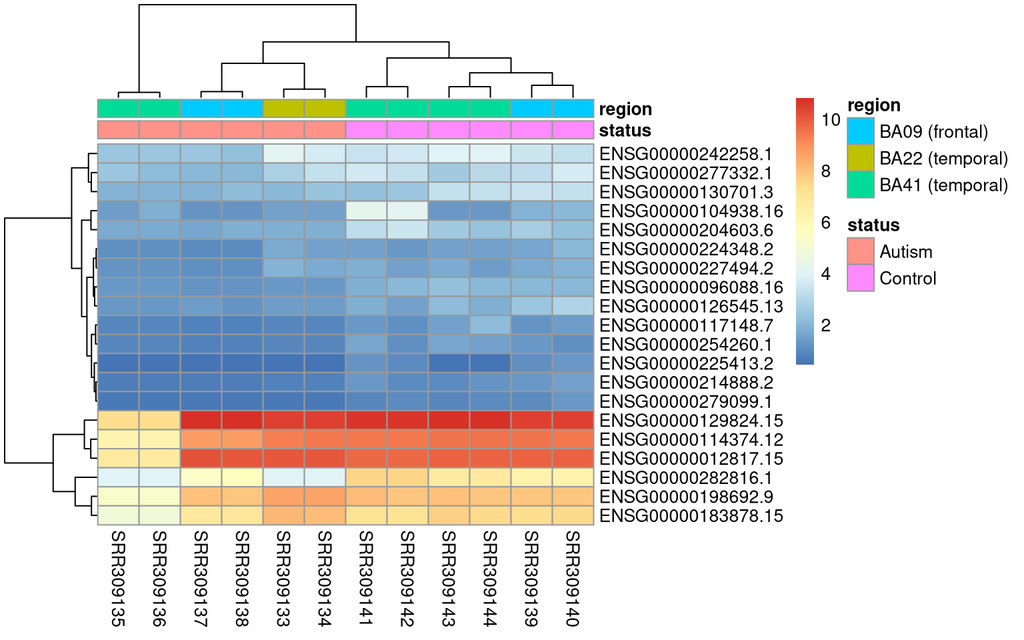

```r
underexpr_deg_counts <- assay(normalized_de_output)[underexpr_degs, ]
pheatmap(underexpr_deg_counts,
    annotation_col = sample_col,
)
```

In the above heatmap, we did not do any extra normalization. The results of DESeq2 are normalized (i.e. values are *log base 2 fold change* of the counts, not counts themselves), and we put those results directly in the heatmap.

In order to make the visualization a bit easier to look at, we’ll normalize using z-scores in each row of the heatmap. We will not do any “column-wise” normalization. This is the resulting heatmap.

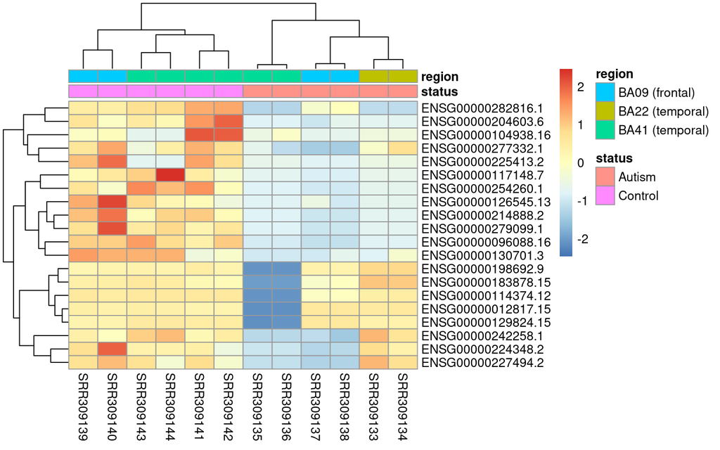

```r
pheatmap(underexpr_deg_counts,
    annotation_col = sample_col,
    scale = "row"
)
```

The result of this normalization is that each row has starker color contrast (e.g. rows are not all blue anymore), allowing us to see the changes with ease.

## 4.2 Most overexpressed genes

This heatmap is similar to the previous one, except we show the 20 most overexpressed genes. Again, we normalize by row, not column.

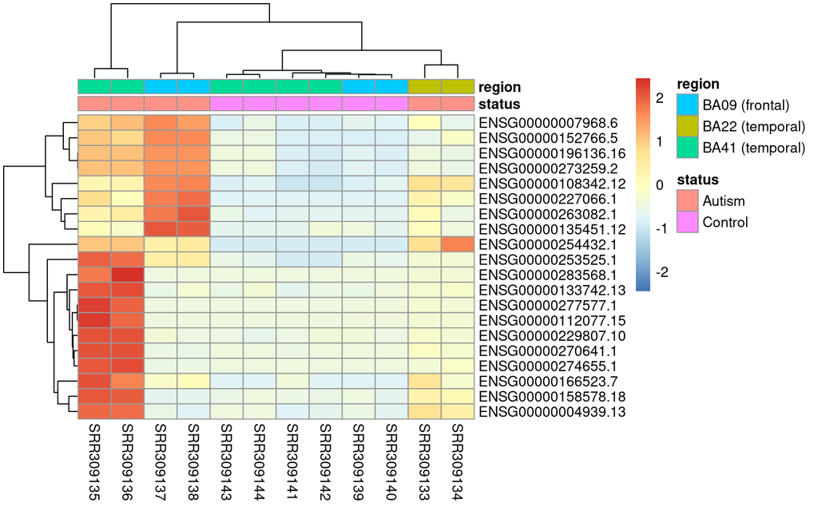

```r
overexpr_deg_counts <- assay(normalized_de_output)[overexpr_degs, ]
pheatmap(overexpr_deg_counts,
    annotation_col = sample_col,
    scale = "row"
)
```

# 5 GSEA

```r
library(org.Hs.eg.db)
```

See how many IDs we lose via taking off the version of the Ensembl ID. We do not lose any!

```r
length(row.names(res))
```

```
## [1] 58037
```

```r
length(unique(row.names(res)))
```

```
## [1] 58037
```

```r
ensembl_ids_without_version <- unique(sub("\\.\\d+$", "", row.names(res)))
length(ensembl_ids_without_version)
```

```
## [1] 58037
```

See how many IDs we lose via conversion from Ensembl ID to gene symbol.

```r
ens2symbol <- AnnotationDbi::select(
    org.Hs.eg.db,
    key = ensembl_ids_without_version,
    columns = "SYMBOL",
    keytype = "ENSEMBL"
)
length(ens2symbol[[1]]) - length(na.omit(ens2symbol)[[1]])
```

```
## [1] 23462
```

I lose a lot of IDs: 23462.

Let’s try converting to Entrez ID instead. Gene sets are available for these as well. Hopefully, we get less loss.

TODO - See how much loss we get from converting to Entrez IDs. -

# 6 Questions

## 6.1 DESeq2

How does DESeq2 work? Why does it work?

## 6.2 GSEA

How does GSEA work? Why does it work?

Is it okay to compare against all the gene sets? Is there a downside to this? I thought I heard that there was.